# Information Value

# Cluster

Cluster chosen: 0 with (23677 rows)

# Information Value

## Prepare frame

Dictionary:

- numeric: 927 features (Numeric)
- categorical: 227 features (Categorical)
- date: 161 features (Date)
- NA_features: 128 features (d_NA)
- Mean_features: 128 features (d_Mean)
- Min_features: 128 features (d_Min)
- MinMin_features: 1 features (d_MinMin)
- Max_features: 128 features (d_Max)
- MaxMax_features: 1 features (d_MaxMax)
- Time0_features: 128 features (d_Time0)
- FirstLast_features: 2 features (d_First, d_Last)
- Timing_features: 128 features (d_Timing)
- TimeToExitStation_features: 128 features (d_TtoE_S)
- TimeToExitProduction_features: 1 features (d_TtoE_P)

Formulas:

- Mutual Information = I(X, Y) = H(X, Y) - H(X | Y) - H(Y | X), understand un-sided
- Conditional Mutual Information = I(X, Y | Z) = H(Z | X) + H(X) + H(Z | Y) + H(Y) - H(Z | X, Y) - H(X, Y) - H(Z) = I(X, Y) + H(Z | X) - H(Z | Y) - H(Z | X, Y) - H(Z), with guarantee of I(X, Y | Z) > 0 and being one-sided

Leak reference: IV = 2.843399 (super large!!!) - 3 splits: [-Inf, -1.5), [-1.5, 164), [164, +Inf]

IV scale:

- over 0.5 = suspicious predictor but possible (literally dominates everything else)
- 0.3-0.5 = strong predictor
- 0.1-0.3 = average predictor
- 0.02-0.1 = weak predictor
- under 0.02 = so weak you mostly cannot do anything with unless you transform them

|  | Feature | Type | Levels | Splits | NotMissing | IG | IV | RankIG | RankIV |
| --- | --- | --- | --- | --- | --- | --- | --- | --- | --- |
| 1 | L0_S0_F0 | Numeric | 117 | 1 | 0.569261843958211 | 7.92619620852975e-05 | 0 | 1047 | 813 |
| 2 | L0_S0_F2 | Numeric | 110 | 1 | 0.569261843958211 | 6.46875427410265e-05 | 0 | 1106 | 813 |
| 3 | L0_S0_F4 | Numeric | 36 | 1 | 0.569261843958211 | 7.51695960623522e-05 | 0 | 1060 | 813 |
| 4 | L0_S0_F6 | Numeric | 37 | 1 | 0.569261843958211 | 7.63375660852717e-05 | 0 | 1055 | 813 |
| 5 | L0_S0_F8 | Numeric | 22 | 1 | 0.569261843958211 | 4.51576039619539e-05 | 0 | 1206 | 813 |
| 6 | L0_S0_F10 | Numeric | 23 | 1 | 0.569261843958211 | 4.11734299206046e-05 | 0 | 1226 | 813 |
| 7 | L0_S0_F12 | Numeric | 29 | 1 | 0.569261843958211 | 5.97872157452883e-05 | 0 | 1128 | 813 |
| 8 | L0_S0_F14 | Numeric | 25 | 1 | 0.569261843958211 | 6.36208207858147e-05 | 0 | 1110 | 813 |
| 9 | L0_S0_F16 | Numeric | 181 | 1 | 0.569261843958211 | 8.64051068152349e-05 | 0 | 1020 | 813 |
| 10 | L0_S0_F18 | Numeric | 175 | 1 | 0.569261843958211 | 9.31787815154905e-05 | 0 | 1000 | 813 |

[output cut: 2206 more lines]

# Look at the splits

Table of 5000 saved rows (lowest absolute inflation value = 3.792915 ):

- variable = Variable
- class = Split
- pct_bin = Percentage of samples included in the split
- good = Count of non-defect in the split
- bad = Count of defects in the split
- bad_rate = Relative count of defects in the split vs population
- inflation = Inflation rate of sample count on rates (thresholded)
- pct_good = Percentage of non-defect in the split
- pct_bad = Percentage of defect in the split
- odds = Odds ratio of the split
- woe = Weight of Evidence of the split
- miv = Information Value of the split

|  | variable | Type | class | pct_bin | good | bad | bad_rate | inflation | pct_good | pct_bad | odds | woe | miv |
| --- | --- | --- | --- | --- | --- | --- | --- | --- | --- | --- | --- | --- | --- |
| 62 | L0_S12_D331 | Date | (-Inf,1379) | 0.00215398910334924 | 49 | 2 | 0.0392156862745098 | 6.14238310708899 | 0.00208094449399074 | 0.0153846153846154 | 7.39309262166405 | 2.00054613478866 | 0.0266146073787395 |
| 65 | L0_S12_F330 | Numeric | [-0.023,0.001) | 0.00147822781602399 | 34 | 1 | 0.0285714285714286 | 4.20373626373626 | 0.0014439206692997 | 0.00769230769230769 | 5.32737556561086 | 1.67285872772318 | 0.0104526687656312 |
| 68 | L0_S12_F332 | Numeric | [-0.057,0.0075) | 0.00320986611479495 | 74 | 2 | 0.0263157894736842 | 3.79291497975709 | 0.00314265086847581 | 0.0153846153846154 | 4.8954261954262 | 1.58830133969512 | 0.0194439286414846 |
| 71 | L0_S12_F334 | Numeric | [-0.061,-0.0465) | 0.0022384592642649 | 51 | 2 | 0.0377358490566038 | 5.87285921625544 | 0.00216588100394955 | 0.0153846153846154 | 7.10316742081448 | 1.96054080017496 | 0.0259158680799709 |
| 90 | L0_S12_F348 | Numeric | [0.081,+Inf) | 0.00143599273556616 | 33 | 1 | 0.0294117647058824 | 4.35678733031674 | 0.0014014524143203 | 0.00769230769230769 | 5.48881118881119 | 1.70271169087286 | 0.0107115128274184 |
| 95 | L0_S13_D355 | Date | (-Inf,1379) | 0.00185834354014444 | 42 | 2 | 0.0454545454545455 | 7.27867132867133 | 0.00178366670913492 | 0.0153846153846154 | 8.62527472527473 | 2.15469681461592 | 0.0293059207868123 |
| 98 | L0_S13_F354 | Numeric | [0.0545,+Inf) | 0.00143599273556616 | 32 | 2 | 0.0588235294117647 | 9.71357466063349 | 0.00135898415934089 | 0.0153846153846154 | 11.3206730769231 | 2.42663053009956 | 0.0340350249351688 |
| 99 | L0_S13_F356 | Numeric | (-Inf,-0.0295) | 0.00316763103433712 | 73 | 2 | 0.0266666666666667 | 3.85682051282051 | 0.00310018261349641 | 0.0153846153846154 | 4.96248682824025 | 1.6019069917509 | 0.0196785187457493 |
| 117 | L0_S15_F397 | Numeric | (-Inf,-0.185) | 0.00139375765510833 | 32 | 1 | 0.0303030303030303 | 4.51911421911422 | 0.00135898415934089 | 0.00769230769230769 | 5.66033653846154 | 1.73348334953961 | 0.0109787108916454 |
| 122 | L0_S15_F403 | Numeric | [0.0935,+Inf) | 0.00139375765510833 | 32 | 1 | 0.0303030303030303 | 4.51911421911422 | 0.00135898415934089 | 0.00769230769230769 | 5.66033653846154 | 1.73348334953961 | 0.0109787108916454 |

[output cut: 4990 more lines]

## Characterstic Plots of Features (Unfacetted)

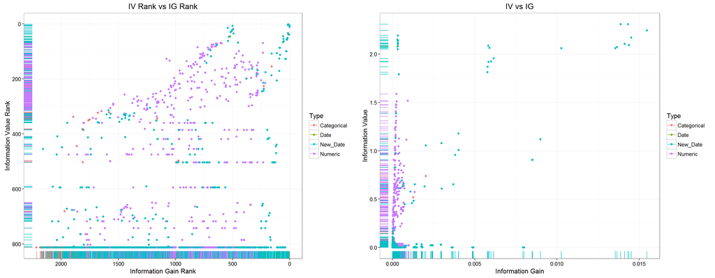

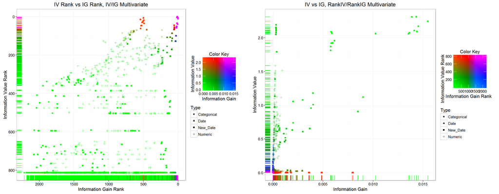

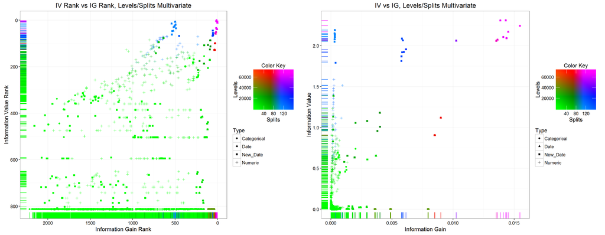

## Characterstic Plots of Features (Facetted)

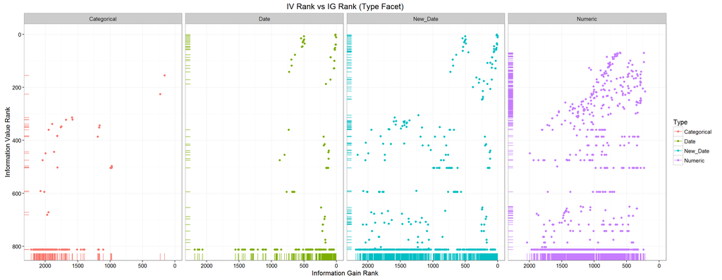

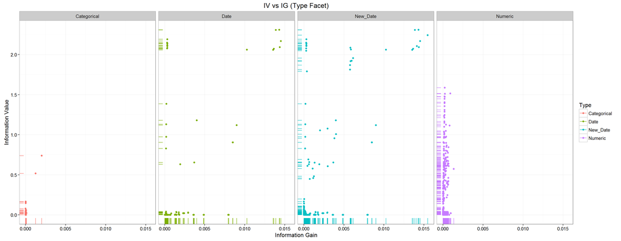

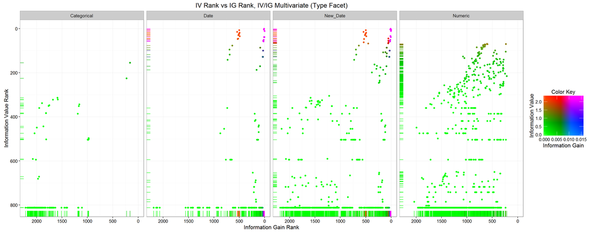

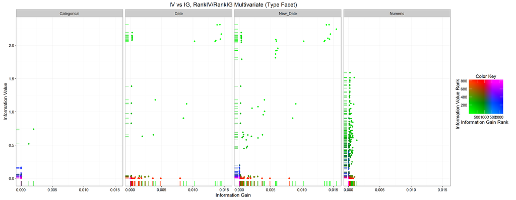

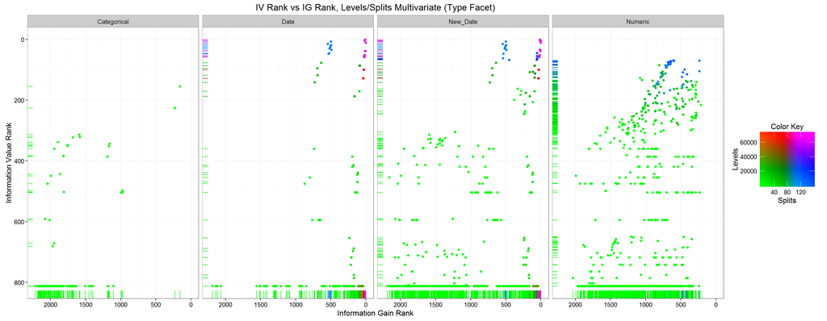

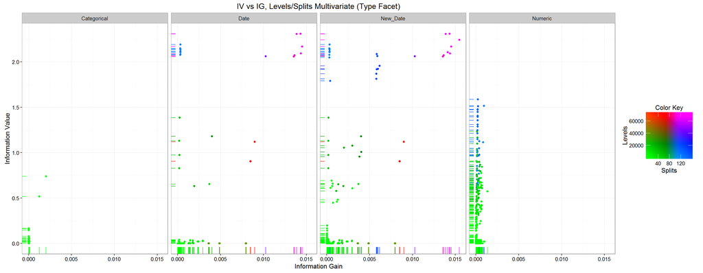

## Characteristic Plots of Splits (Unfacetted)

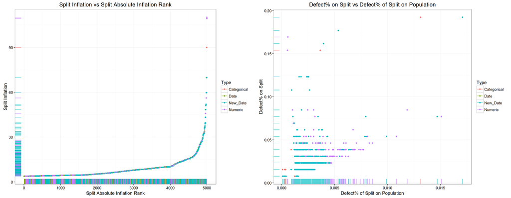

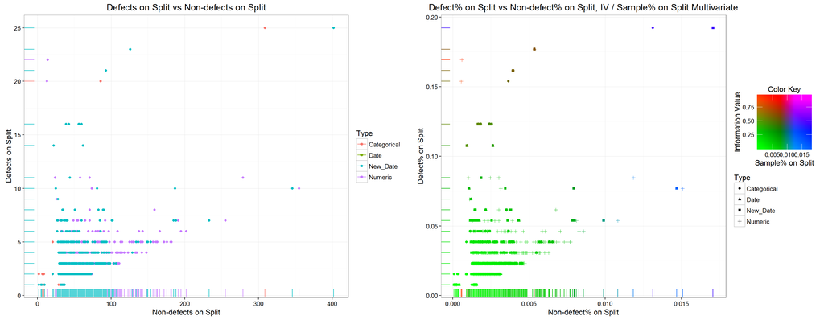

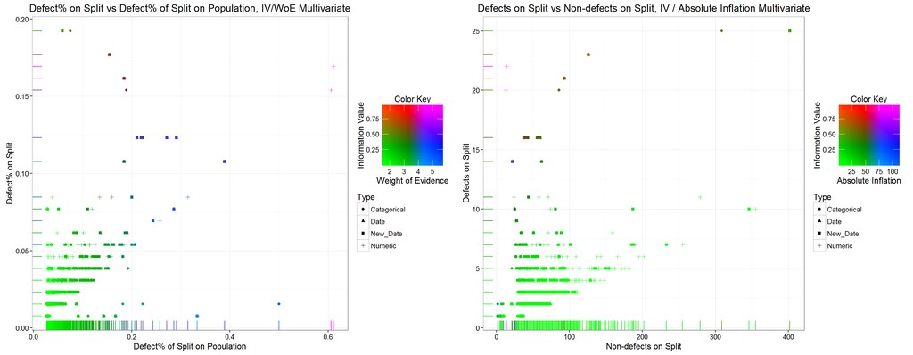

## Characteristic Plots of Splits (Facetted)

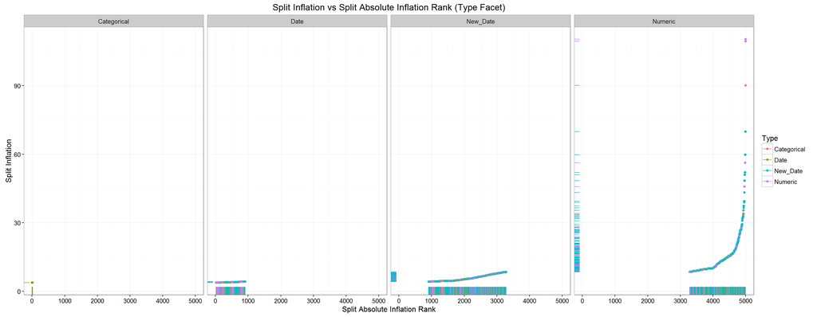

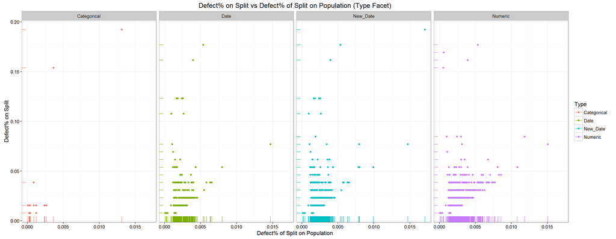

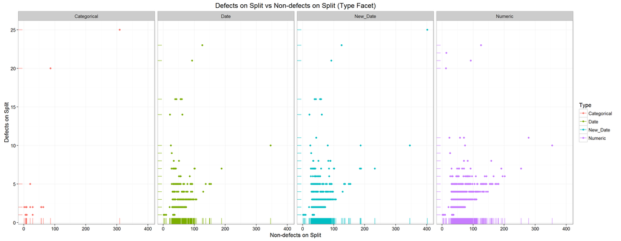

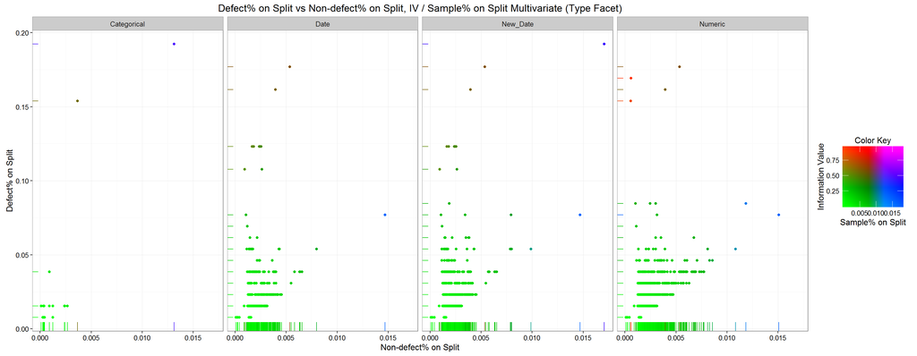

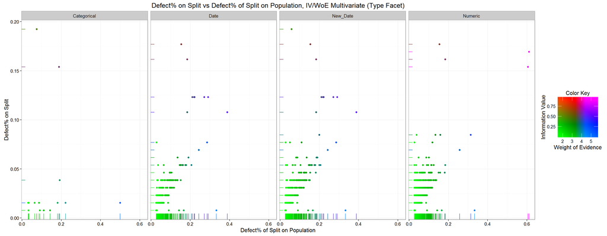

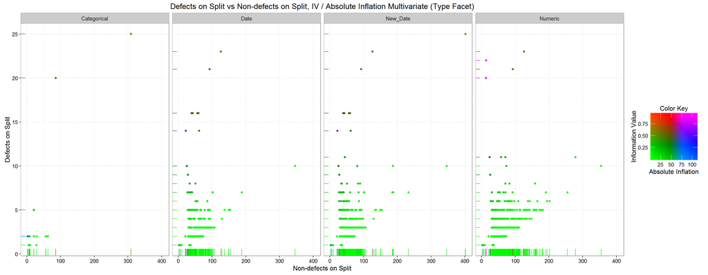